# Badania eksperymentalne wątpliwych amyloidów

## Cel pracy

Sprawdzenie poprawności predykcji poprzez analizę sekwencji zdeponowanych w bazie AmyLoad.

Wybrane zostały 24 peptydy, które miały najniższy lub najwyższy wynik. 13 pozytywnych oraz 11 negatywnych.

Badania mają na celu kalibrację algorytmu AmyloGramu.

## Sposób wybrania 24 peptydów

- z bazy AmyLoad pobraliśmy wszystkie sekwencje
- zbiór został podzielony na 2 grupy
- sprawdziliśmy czy sekwencje nie powtarzają się w obu grupach
- sekwencje przekształciliśmy przy wykorzystaniu zredukowanych alfabetów
- usuneliśmy duplikaty
- policzyliśmy wartości predykcji

## Sposób wybrania 24 peptydów - schemat

[figure not shown]

## AmyLoad - podwójna adnotacja

[figure not shown]

## Metody

Do sprawdzenia właściwości amyloidogennych użyliśmy metody ThT.

W późniejszych etapach użyty zostanie FTIR oraz AFM.

Peptydy podczas syntezy de novo mogły zagregować. Do zaburzenia struktury III-rzędowej powszechnie stosowany jest NaOH.

## Peptydy wzorcowe

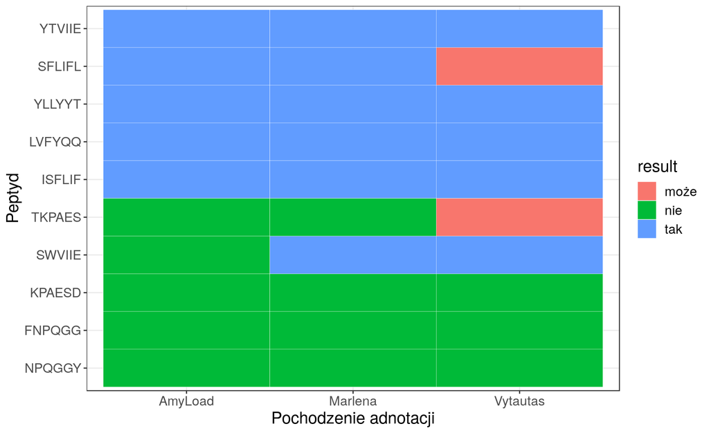

[figure not shown]

## 24 peptydy

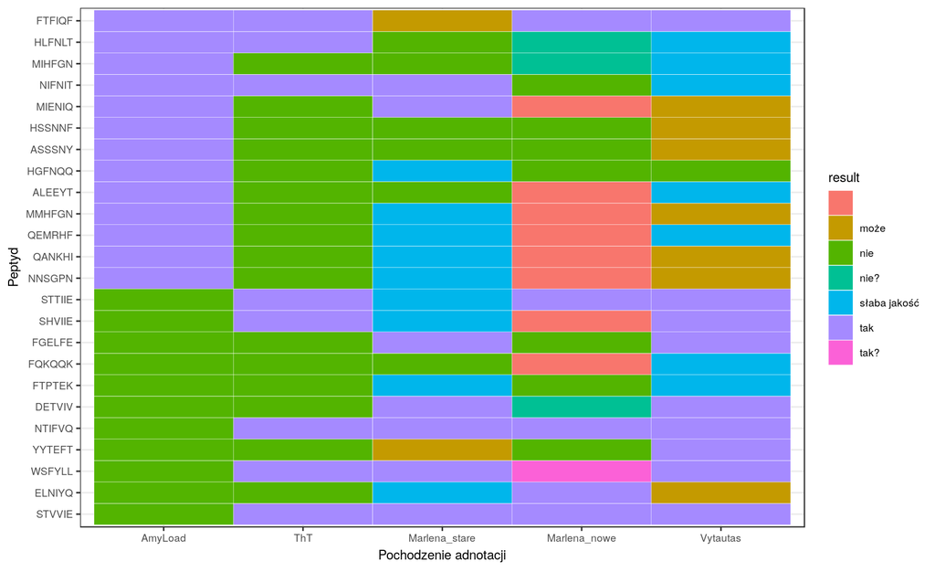

## Intensywnośc fluorescencji peptydow

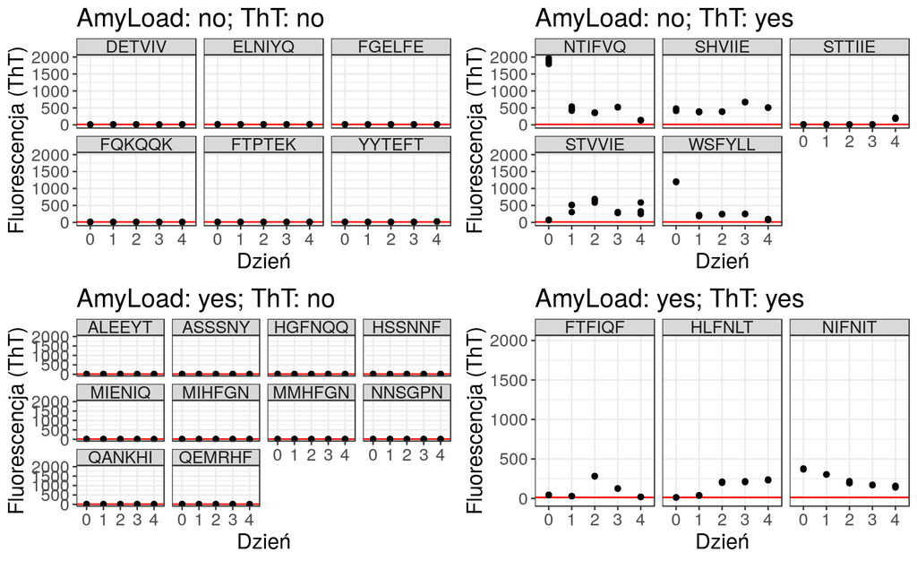

## Intensywnośc fluorescencji peptydow

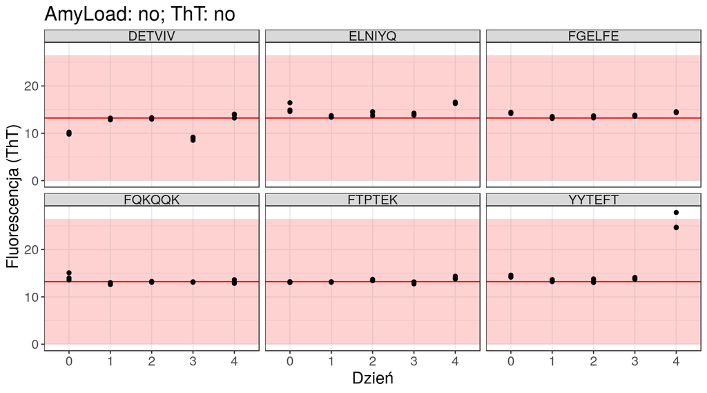

## Intensywnośc fluorescencji peptydow

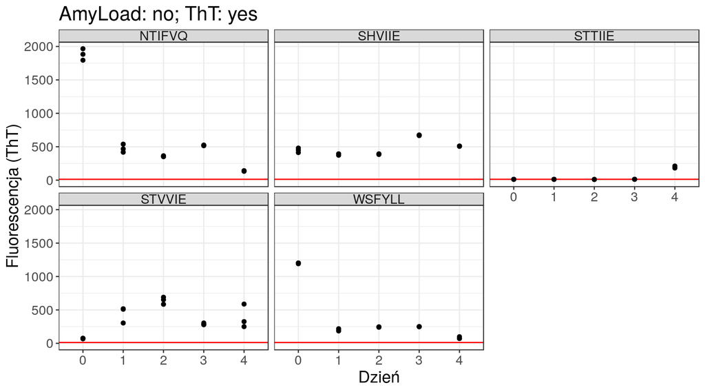

## Intensywnośc fluorescencji peptydow

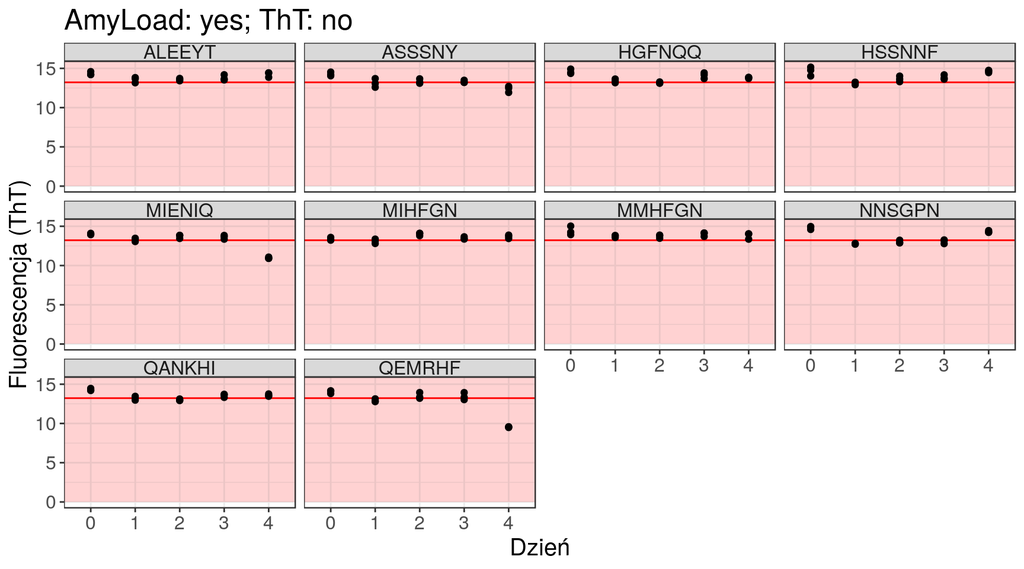

## Intensywnośc fluorescencji peptydow

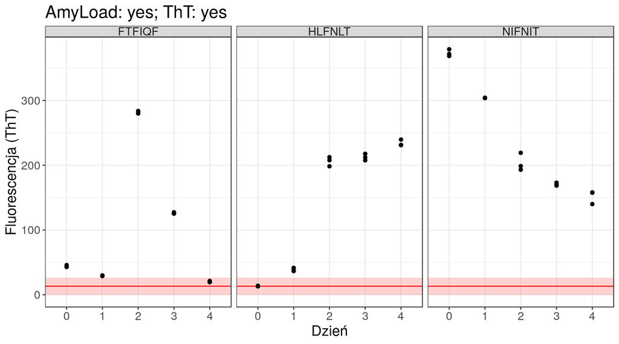

## Wyniki barwienia ThT

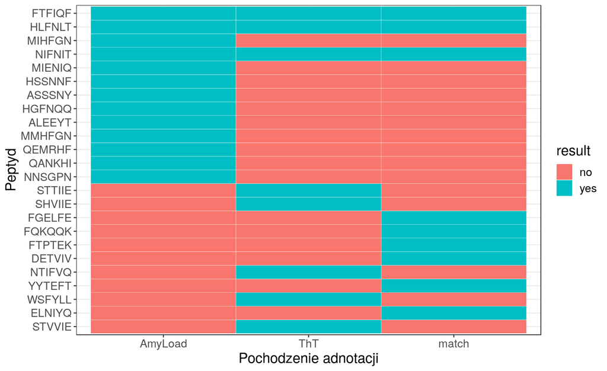

## Dalsze prace

Peptydy, które według bazy AmyLoad są nieamyloidogenne, a dały pozytywny wynik w kontakcie z ThT zostaną przebadane na AFM.

W późniejszych etapach badania będą prowadzone nad całymi białkami csgA. Obecnie opracowywany jest wydajny protokół izolacji i oczyszczenia.

## AFM

[figure not shown]

## Dalsze prace - peptydy

Przedział ufności dla predykcji: (Quantifying Uncertainty in Random Forests via Confidence Intervals and Hypothesis Tests, Journal of Machine Learning Research, 2016).

Wysokie/niskie prawdopodobieństwo nie przekłada się na pewność predykcji.

## Dalsze prace - peptydy

Jakie motywy aminokwasowe wpłynęły na ocenę peptydów? Jak bardzo podobne peptydy zostaly ocenione przeciwnie?

## Dalsze prace - peptydy

Analiza bibliograficzna: powtórzenie badań peptydów uwzględniając warunki reakcji ze zgłaszających ich publikacji.